# Dataset Overview

# Bike rides per member age group

```python
trip_by_age_df = df.groupby('member_age_bins').agg({'bike_id':'count'})
trip_by_age_df['perc'] = (trip_by_age_df['bike_id']/trip_by_age_df['bike_id'].sum())*100
```

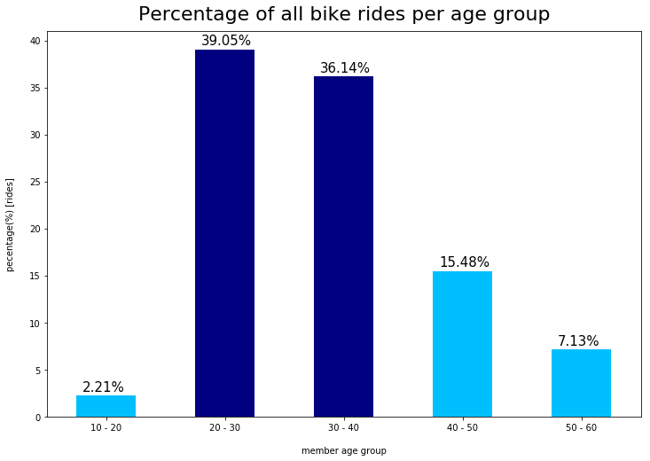

```python
new_color = ['deepskyblue', 'navy', 'navy', 'deepskyblue', 'deepskyblue']
ax=trip_by_age_df['perc'].plot(kind='bar', color=new_color, figsize=(12,8))
plt.title('Percentage of all bike rides per age group', fontsize=22, y=1.015)
plt.xlabel('member age group', labelpad=16)
plt.ylabel('pecentage(%) [rides]', labelpad=16)
plt.xticks(rotation=360)
# create a list to collect the plt.patches data
totals = []

# find the values and append to list
for i in ax.patches:
    totals.append(i.get_height())

# set individual bar lables using above list
total = sum(totals)

# set individual bar lables using above list
for i in ax.patches:
    # get_x pulls left or right; get_height pushes up or down
    ax.text(i.get_x()+.05, i.get_height()+.5, \
            str(round((i.get_height()/total)*100, 2))+'%', fontsize=15,
                color='Black')
```

```python
df=df.reset_index(drop=True)
```

```python
df.head()
```

|  | duration_sec | start_time | end_time | start_station_id | start_station_name | start_station_latitude | start_station_longitude | end_station_id | end_station_name | end_station_latitude | end_station_longitude | bike_id | user_type | member_gender | bike_share_for_all_trip | member_age | start_time_date | end_time_date | start_time_year_month_renamed | member_age_bins |
| --- | --- | --- | --- | --- | --- | --- | --- | --- | --- | --- | --- | --- | --- | --- | --- | --- | --- | --- | --- | --- |
| 0 | 714 | 2018-01-01 00:07:52.943 | 2018-01-01 00:19:47.075 | 74.0 | Laguna St at Hayes St | 37.776435 | -122.426244 | 70.0 | Central Ave at Fell St | 37.773311 | -122.444293 | 2423 | Subscriber | Male | No | 32.0 | 2018-01-01 | 2018-01-01 | 18-01 | 30 - 40 |
| 1 | 1151 | 2018-01-01 00:09:31.745 | 2018-01-01 00:28:43.159 | 97.0 | 14th St at Mission St | 37.768265 | -122.420110 | 125.0 | 20th St at Bryant St | 37.759200 | -122.409851 | 3455 | Subscriber | Male | No | 26.0 | 2018-01-01 | 2018-01-01 | 18-01 | 20 - 30 |
| 2 | 1359 | 2018-01-01 00:14:37.187 | 2018-01-01 00:37:16.445 | 11.0 | Davis St at Jackson St | 37.797280 | -122.398436 | 323.0 | Broadway at Kearny | 37.798014 | -122.405950 | 2173 | Customer | Male | No | 23.0 | 2018-01-01 | 2018-01-01 | 18-01 | 20 - 30 |
| 3 | 2603 | 2018-01-01 00:15:33.369 | 2018-01-01 00:58:56.522 | 17.0 | Embarcadero BART Station (Beale St at Market St) | 37.792251 | -122.397086 | 8.0 | The Embarcadero at Vallejo St | 37.799953 | -122.398525 | 1788 | Subscriber | Male | Yes | 24.0 | 2018-01-01 | 2018-01-01 | 18-01 | 20 - 30 |
| 4 | 2478 | 2018-01-01 00:17:54.588 | 2018-01-01 00:59:13.448 | 17.0 | Embarcadero BART Station (Beale St at Market St) | 37.792251 | -122.397086 | 8.0 | The Embarcadero at Vallejo St | 37.799953 | -122.398525 | 1586 | Subscriber | Female | Yes | 25.0 | 2018-01-01 | 2018-01-01 | 18-01 | 20 - 30 |

```python
import datetime
import time
times=[datetime.time(6,0,0),datetime.time(12,0,0),datetime.time(15,0,0),datetime.time(20,0,0),datetime.time(23,0,0)]
times
df['time']=df['start_time'].dt.time
df['day_interval']=df['time']
```

```python
df.loc[(df['time'] >= times[0]) & (df['time'] < times[1]),
       'day_interval'] = "Morning"
df.loc[(df['time'] >= times[1]) & (df['time'] < times[2]),
       'day_interval'] = "Afternoon"
df.loc[(df['time'] >= times[2]) & (df['time'] < times[3]),
       'day_interval'] = "Evening"
df.loc[(df['time'] >= times[3]) & (df['time'] < times[4]),
       'day_interval'] = "Night"
df.loc[(df['time'] >= times[4]),
       'day_interval'] = "Late Night"
df.loc[(df['time'] < times[0]),
       'day_interval'] = "Early Hours"
```

```python
df
```

[output not shown]

1549293 rows × 22 columns

```python
df.shape[0]
```

```
1549293
```

```python
subscriber=df.query('user_type=="Subscriber"')
customer=df.query('user_type=="Customer"')
```

# Total Trips of different types of suscribers based on time of the day

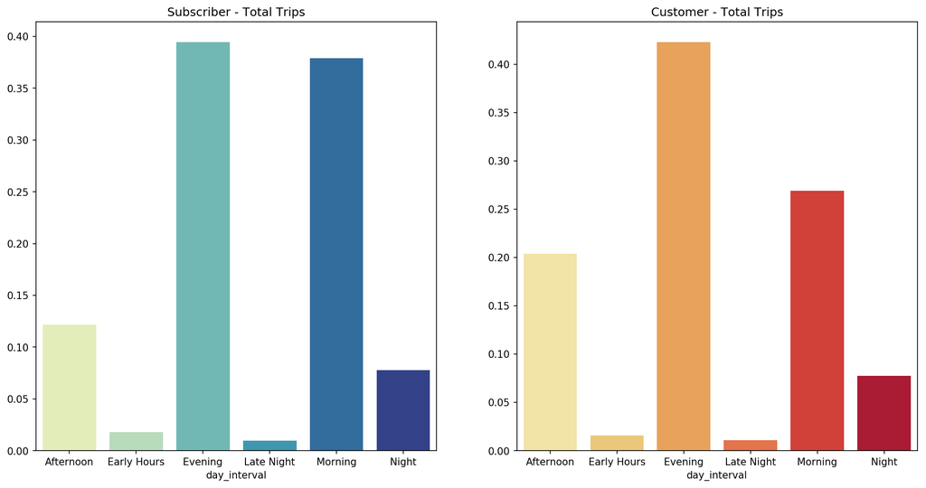

```python
fig, axes = plt.subplots(figsize=(16,8),nrows=1, ncols=2,dpi=150)


plot1 = df[(df.user_type == 'Subscriber')].groupby('day_interval').time.count()
pl1=[]
total_subs=df[(df.user_type == 'Subscriber')].time.count()
for i in plot1:
    pl1.append(i/total_subs)
ax1 = sns.barplot(y=pl1,x=plot1.index, ax = axes[0], palette='YlGnBu').set_title('Subscriber - Total Trips')

plot2 = df[(df.user_type == 'Customer')].groupby('day_interval').time.count()
pl2=[]
total_cust=df[(df.user_type == 'Customer')].time.count()
for i in plot2:
    pl2.append(i/total_cust)

ax2 = sns.barplot(y=pl2,x=plot2.index, ax = axes[1], palette='YlOrRd').set_title('Customer - Total Trips')
```

We see that majority of riders ride during the Mornings or evenings

# Bike rides per hours of the day

```python
trip_by_hour_df =df['start_time'].dt.hour
trip_hr=trip_by_hour_df.unique()
hr_ct=trip_by_hour_df.value_counts()
trip_by_hour_df=trip_by_hour_df.to_frame()
#trip_hr=trip_by_hour_df.value_counts()
for i in range (0,len(trip_hr)):
    trip_by_hour_df.loc[(trip_by_hour_df['start_time'] == trip_hr[i]),'value_counts'] = hr_ct[i]
#trip_hr
trip_by_hour_df=trip_by_hour_df.drop_duplicates().reset_index()
trip_by_hour_df['%age'] = (trip_by_hour_df['value_counts']/trip_by_hour_df['value_counts'].sum())*100
```

```
Text(0,0.5,'percentage(%) [rides]')
```

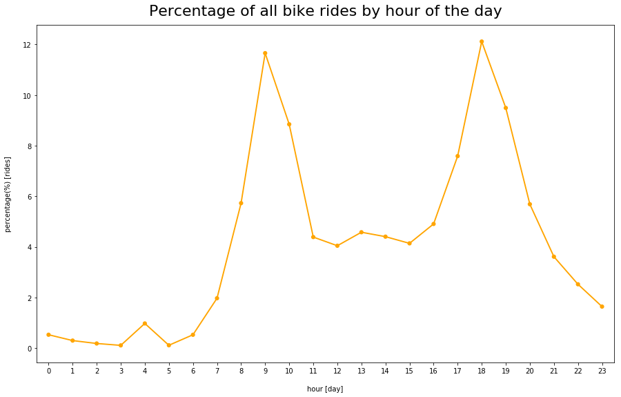

```python
plt.figure(figsize=(15,9))
sns.pointplot(x='start_time', y='%age', scale=.7, color='orange', data=trip_by_hour_df)
plt.title('Percentage of all bike rides by hour of the day', fontsize=22, y=1.015)
plt.xlabel('hour [day]', labelpad=16)
plt.ylabel('percentage(%) [rides]', labelpad=16)
```

```python
trip_by_hour_df
```

|  | index | start_time | value_counts | %age |
| --- | --- | --- | --- | --- |
| 0 | 0 | 0 | 8165.0 | 0.527015 |
| 1 | 27 | 1 | 4590.0 | 0.296264 |
| 2 | 53 | 2 | 2810.0 | 0.181373 |
| 3 | 73 | 3 | 1654.0 | 0.106758 |
| 4 | 84 | 5 | 1718.0 | 0.110889 |
| 5 | 88 | 6 | 8146.0 | 0.525788 |
| 6 | 95 | 7 | 30500.0 | 1.968640 |
| 7 | 99 | 8 | 88713.0 | 5.726031 |
| 8 | 119 | 9 | 180541.0 | 11.653122 |
| 9 | 146 | 10 | 136984.0 | 8.841710 |
| 10 | 201 | 11 | 67948.0 | 4.385742 |
| 11 | 256 | 12 | 62642.0 | 4.043264 |
| 12 | 320 | 13 | 70909.0 | 4.576862 |
| 13 | 394 | 14 | 68203.0 | 4.402202 |
| 14 | 498 | 15 | 64106.0 | 4.137758 |
| 15 | 604 | 16 | 75975.0 | 4.903850 |
| 16 | 697 | 17 | 117510.0 | 7.584750 |
| 17 | 778 | 18 | 187646.0 | 12.111718 |
| 18 | 827 | 19 | 147004.0 | 9.488457 |
| 19 | 864 | 20 | 88067.0 | 5.684335 |
| 20 | 899 | 21 | 55936.0 | 3.610421 |
| 21 | 937 | 22 | 39062.0 | 2.521279 |
| 22 | 951 | 23 | 25392.0 | 1.638941 |
| 23 | 965 | 4 | 15072.0 | 0.972831 |

We see during morning hours **9 am** is the time when peole ride their bikes the most around **11.65%**

We see during evening hours **6 pm** is the time when peole ride their bikes the most around **12.11%**

```python
df['hour']=df['start_time'].dt.hour
df['weekday']=df['start_time'].dt.weekday
df.info()
```

```
<class 'pandas.core.frame.DataFrame'>
RangeIndex: 1549293 entries, 0 to 1549292
Data columns (total 24 columns):
duration_sec                     1549293 non-null int64
start_time                       1549293 non-null datetime64[ns]
end_time                         1549293 non-null datetime64[ns]
start_station_id                 1549293 non-null float64
start_station_name               1549293 non-null object
start_station_latitude           1549293 non-null float64
start_station_longitude          1549293 non-null float64
end_station_id                   1549293 non-null float64
end_station_name                 1549293 non-null object
end_station_latitude             1549293 non-null float64
end_station_longitude            1549293 non-null float64
bike_id                          1549293 non-null int64
user_type                        1549293 non-null object
member_gender                    1549293 non-null object
bike_share_for_all_trip          1549293 non-null object
member_age                       1549293 non-null float64
start_time_date                  1549293 non-null object
end_time_date                    1549293 non-null object
start_time_year_month_renamed    1549293 non-null object
member_age_bins                  1549293 non-null object
time                             1549293 non-null object
day_interval                     1549293 non-null object
hour                             1549293 non-null int64
weekday                          1549293 non-null int64
dtypes: datetime64[ns](2), float64(7), int64(4), object(11)
memory usage: 283.7+ MB
```

```python
subscriber_hour_df = df[(df['member_age']>=20) & (df['member_age']<40)
                              &(df['hour']>5)&(df['user_type']=='Subscriber')
                             ].groupby(['weekday', 'start_time']).agg({'bike_id' : 'count'}).rename(columns={'bike_id':'count'}).reset_index()
```

```python
subscriber_hour_df['hour']=subscriber_hour_df['start_time'].dt.hour
```

```python
'''
subscriber_hour_df.loc[(subscriber_hour_df['weekday']==0),'weekday']="Mo"
subscriber_hour_df.loc[(subscriber_hour_df['weekday']==1),'weekday']="Tu"
subscriber_hour_df.loc[(subscriber_hour_df['weekday']==2),'weekday']="We"
subscriber_hour_df.loc[(subscriber_hour_df['weekday']==3),'weekday']="Th"
subscriber_hour_df.loc[(subscriber_hour_df['weekday']==4),'weekday']="Fr"
subscriber_hour_df.loc[(subscriber_hour_df['weekday']==5),'weekday']="Sa"
subscriber_hour_df.loc[(subscriber_hour_df['weekday']==6),'weekday']="Su"

subscriber_hour_df'''
```

[output not shown]

```python
subscriber_hour_df_pivoted=subscriber_hour_df.groupby(['hour','weekday']).size().reset_index(name='count')
subscriber_hour_df_pivoted=subscriber_hour_df_pivoted.pivot_table(index='hour', columns='weekday', values='count').astype(int)
```

```python
customer_hour_df = df[(df['member_age']>=20) & (df['member_age']<40)
                              &(df['hour']>5)&(df['user_type']=='Customer')
                             ].groupby(['weekday', 'start_time']).agg({'bike_id' : 'count'}).rename(columns={'bike_id':'count'}).reset_index()
```

```python
customer_hour_df['hour']=customer_hour_df['start_time'].dt.hour
```

```python
'''
customer_hour_df.loc[(customer_hour_df['weekday']==0),'weekday']="Mo"
customer_hour_df.loc[(customer_hour_df['weekday']==1),'weekday']="Tu"
customer_hour_df.loc[(customer_hour_df['weekday']==2),'weekday']="We"
customer_hour_df.loc[(customer_hour_df['weekday']==3),'weekday']="Th"
customer_hour_df.loc[(customer_hour_df['weekday']==4),'weekday']="Fr"
customer_hour_df.loc[(customer_hour_df['weekday']==5),'weekday']="Sa"
customer_hour_df.loc[(customer_hour_df['weekday']==6),'weekday']="Su"
'''
```

[output not shown]

```python
customer_hour_df_pivoted=customer_hour_df.groupby(['hour','weekday']).size().reset_index(name='count')
customer_hour_df_pivoted=customer_hour_df_pivoted.pivot_table(index='hour', columns='weekday', values='count').astype(int)
```

## Most frequently used timing per user type for 20~40 age people

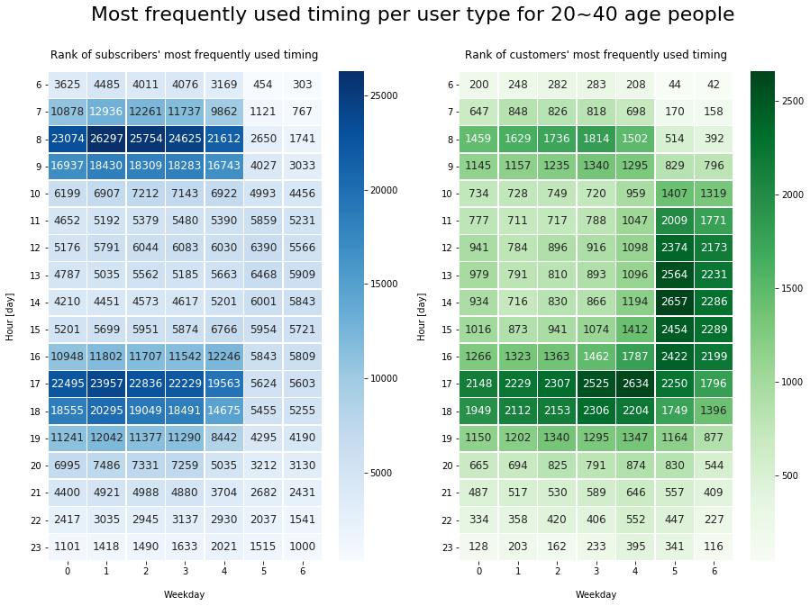

```python
plt.figure(figsize=(15,10))
plt.subplot(121)
plt.suptitle('Most frequently used timing per user type for 20~40 age people', fontsize=22)
sns.heatmap(subscriber_hour_df_pivoted, fmt='d', annot=True, cmap='Blues', annot_kws={"size": 12},linewidths=.5)
plt.title("Rank of subscribers' most frequently used timing", y=1.015)
plt.xlabel('Weekday', labelpad=16)
plt.ylabel('Hour [day]', labelpad=16)
plt.yticks(rotation=360)

plt.subplot(122)
sns.heatmap(customer_hour_df_pivoted, fmt='d', annot=True, cmap='Greens', annot_kws={"size": 12},linewidths=.5)
plt.title("Rank of customers' most frequently used timing", y=1.015)
plt.xlabel('Weekday', labelpad=16)
plt.ylabel('Hour [day]', labelpad=16)
plt.yticks(rotation=360)
```

We see maximum subscribers prefer to ride the bikes on weekdays and generally in morning atround 7-9 am and in evening 4-7 pm

We also see the customerd generally ride during the weekends